# PSCI 3200 Final Report Checkpoint 2

Author

Affiliation

Ki Joon Lee

University of Pennsylvania

Published

April 23, 2024

## Research Question

Do organizations pivot their degree of political engagement upon receiving funding from the government? I became intrigued how the NGO’s source of revenue affects the degree to which they partake in political activity. According to [Mahmood and Gull (2016)](https://www.researchgate.net/publication/309096522_Government_Funding_to_the_NGOs_A_Blessing_or_a_Curse), NGO’s express that government funding, despite the financial stability it provides, has decreased their autonomy to pursue its missions. In addition, [Bloodgood and Boire (2016)](https://www.researchgate.net/publication/309096522_Government_Funding_to_the_NGOs_A_Blessing_or_a_Curse) found that increase in government funding was negatively associated with NGO lobbying expenditures. In the end, exploring how powerful government funding is in influencing the political activity of the NGO is critical to determining if state funding for NGO’s is a net gain or loss for society. I will use the data collected from 86 Cambodian Civil Society Organizations (CSO) to examine this relationship.

## Hypothesis

Does increased financial contribution from Cambodian government have a negative association with the political engagement of Cambodian CSO’s? I suspect this relationship because the more money the CSO gets from the government, the more difficult it is for it to engage in political activity that may jeopardize that money. According to [Freedom House](https://freedomhouse.org/country/cambodia/freedom-world/2024), open criticism of the prime minister or the government can result in reprisals, and the state power is often internally unchecked. The Cambodian government may retract its awards or contracts when a CSO expresses criticism of the state.

## Variables

There are two sources of CSO revenue coming from the Cambodian government: awards and income from CSO services to the Cambodian government. These measures can be used as independent variables to estimate how financially dependent the organization is on the domestic government.

Meanwhile, the data also offers CSOs’ survey response to questions asking if the CSO engages in activities related to political engagement, which could be neutral, sensitive to the government or creating tensions with the government. These responses can be used as the dependent variable in our hypothesis.

```r
revenue <- budget %>%
  rename(
    international_award = award.amount.received_5..International.NGOs..INGOs..and.Foundations,
    foreign_award = award.amount.received_4..Other.foreign.government.donors.or.multilateral.organizations,
    domestic_award = award.amount.received_6..Domestic.NGOs.and.Foundations,
    us_award = award.amount.received_1..United.States,
    other_award = award.amount.received_8..Other,
    cambodia_award = award.amount.received_7..Royal.Government.of.Cambodia,
    rental_income = income.amount_7..Income.from.renting.out.property..vehicles..or.equipment.owned.by.the.organization,
    interest_income = income.value_8..Income.from.bank.interest.paid,
    fundraiser_income = income.value_5..Income.from.fundraisers.or.other.special.events.,
    other_income = income.value_9..Other,
    fees_income = income.value_2..Fees.paid.by.recipients.of.services.rendered.by.the.organization.,
    sale_income = income.value_6..Income.from.the.sale.of.goods.and.other.commercial.activities.,
    membership_income = income.value_1..Membership.fees.and.dues,
    services_gov_income = income.value_3..Income.from.services.rendered.to.the.government.,
    services_ngo_income = income.value_4..Income.from.services.rendered.to.another.NGO.community.based.organization.,
    foreign_ind_donation = donation.value_1..Foreign.individuals,
    foreign_biz_donation = donation.value_2..Foreign.business,
    ingo_donation = donation.value_6..International.NGOs..INGOs..and.Foundations,
    cambodian_ind_donation = donation.value_3..Cambodian.individuals,
    cambodian_biz_donation = donation.value_4..Cambodian.business,
    ngo_donation = donation.value_7..Domestic.NGOs.and.Foundations,
    other_donation = donation.value_5..Anonymous.Other) %>%
  select(organization_id, year, contains("_award"), contains("_income"), contains("_donation")) %>%
  mutate_all(~replace(., is.na(.), 0)) %>% # NA actually means 0 money.
  mutate(total_revenue = international_award + foreign_award + domestic_award + us_award + other_award + cambodia_award + interest_income + rental_income + fundraiser_income + other_income + fees_income + sale_income + membership_income + services_gov_income + services_ngo_income + foreign_ind_donation + foreign_biz_donation + ingo_donation + cambodian_ind_donation + cambodian_biz_donation + ngo_donation + other_donation,
         international_revenue = international_award + foreign_award + us_award + foreign_ind_donation + foreign_biz_donation + ingo_donation,
         domestic_revenue = cambodia_award + services_gov_income,
         pct_domestic = domestic_revenue/total_revenue,
         pct_international = international_revenue/total_revenue,
         international = ifelse(pct_international >= 0.7, 1, 0))

revenue_2019 <- revenue %>%
  filter(year == 2019)

revenue_2021 <- revenue %>%
  filter(year == 2021)

merged_award <- merge(revenue_2019, revenue_2021, by = "organization_id")

revenue_final <- merged_award %>%
  select(organization_id, year.x, pct_domestic.x, pct_international.x, international.x, year.y, pct_domestic.y, pct_international.y, international.y) %>%
  mutate(pct_international.mean = (pct_international.y + pct_international.x)/2,
         pct_domestic.mean = (pct_domestic.x + pct_domestic.y)/2,
         pct_change = pct_international.y - pct_international.x)
```

```r
standing <- survey %>%
  rename(organization_id = Q1_2,
         sensitive = Q77,
         tension_work = Q78,
         tension_community = Q79,
         political_action = Q76_2) %>%
  select(organization_id, sensitive, tension_work, tension_community, political_action) %>%
  mutate(sensitive = case_when(
    sensitive == "Yes" ~ 1,
    sensitive == "No" ~ 0,
    TRUE ~ NA)) %>%
  mutate(tension_work = case_when(
    tension_work == "Yes" ~ 1,
    tension_work == "No" ~ 0,
    TRUE ~ NA)) %>%
  mutate(tension_community = case_when(
    tension_community == "Yes" ~ 1,
    tension_community == "No" ~ 0,
    TRUE ~ NA)) %>%
  mutate(political_action = case_when(
    political_action == "For most projects" ~ 1,
    political_action == "For some projects" ~ 1,
    political_action == "Never" ~ 0,
    TRUE ~ NA)) %>%
  mutate(political_index = political_action + sensitive + tension_work + tension_community,
         political = ifelse(political_index > 0, 1, 0))

final <- merge(revenue_final, standing, by = "organization_id")
```

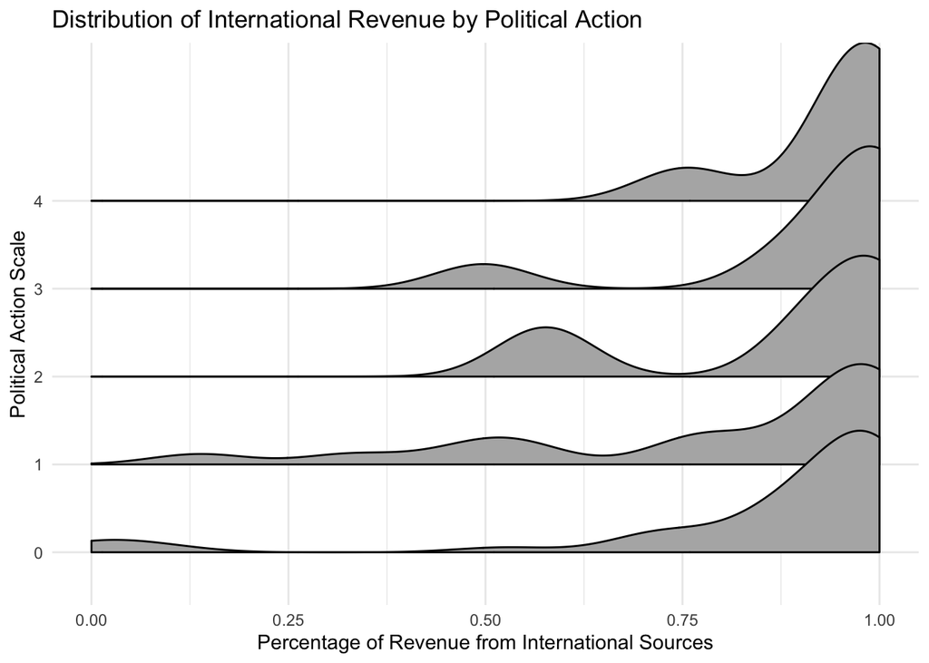

```r
library(ggridges)

plot1 <- ggplot(final, aes(y = factor(political_index), x = pct_international.mean)) +
  geom_density_ridges2(from = 0, to = 1)+
  labs(
    title = "Distribution of International Revenue by Political Action",
    y = "Political Action Scale",
    x = "Percentage of Revenue from International Sources"
  ) +
  theme_minimal()

plot2 <- ggplot(final, aes(y = factor(political_index), x = pct_domestic.mean)) +
  geom_density_ridges2(from = 0, to = 1)+
  labs(
    title = "Distribution of Domestic Revenue by Political Action",
    y = "Political Action Scale",
    x = "Percentage of Revenue from Domestic Sources"
  ) +
  theme_minimal()

ggsave("plot1.png", plot1, width = 8, height = 6)
ggsave("plot2.png", plot2, width = 8, height = 6)
print(plot1)
```

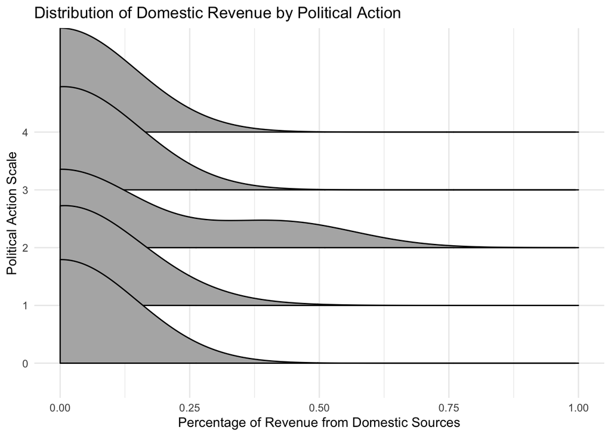

```r
print(plot2)
```

## Regression

I will explore the correlation between level of political engagement and government funding, as well as international funding, through the following regression model.

$$Political Engagement = \beta_0 + \beta_1 Government Funding + \beta_2 International Funding + \epsilon$$